# 8. Exponential smoothing

## Forecasting with ETS models Example: Corticosteroid drug sales

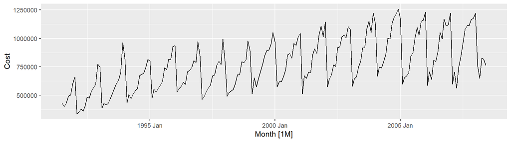

```r
h02 <- PBS |>
  filter(ATC2 == "H02") |>
  summarise(Cost = sum(Cost))
h02 |> autoplot(Cost)
```

We start by directly asking the fable package for an ETS model:

```r
h02 |>
  model(ETS(Cost)) |>
  report()
```

```
## Series: Cost
## Model: ETS(M,Ad,M)
##   Smoothing parameters:
##     alpha = 0.3071016
##     beta  = 0.0001006793
##     gamma = 0.0001007181
##     phi   = 0.977528
##
##   Initial states:
##      l[0]    b[0]      s[0]     s[-1]     s[-2]     s[-3]     s[-4]    s[-5]
##  417268.7 8205.82 0.8716807 0.8259747 0.7562808 0.7733338 0.6872373 1.283821
##     s[-6]    s[-7]    s[-8]    s[-9]   s[-10]    s[-11]
##  1.324616 1.180067 1.163601 1.104801 1.047963 0.9806235
##
##   sigma^2:  0.0046
##
##      AIC     AICc      BIC
## 5515.212 5518.909 5574.938
```

Next we instead choose a model, namely with additive error, additive seasonality and additive trend:

```r
h02 |>
  model(ETS(Cost ~ error("A") + trend("A") + season("A"))) |>
  report()
```

```
## Series: Cost
## Model: ETS(A,A,A)
##   Smoothing parameters:
##     alpha = 0.1702163
##     beta  = 0.006310854
##     gamma = 0.4545987
##
##   Initial states:
##      l[0]     b[0]      s[0]     s[-1]     s[-2]     s[-3]     s[-4]    s[-5]
##  409705.9 9097.111 -99075.37 -136602.3 -191496.1 -174530.8 -241436.7 210643.8
##     s[-6]    s[-7]    s[-8]    s[-9]  s[-10]    s[-11]
##  244644.2 145368.2 130569.6 84457.69 39131.7 -11673.71
##
##   sigma^2:  3498869384
##
##      AIC     AICc      BIC
## 5585.278 5588.568 5641.686
```

The AICc value is now quite a bit bigger, indicating that the model does not fit as well as the previous one.

Let’s check the forecast of the actually chosen model:

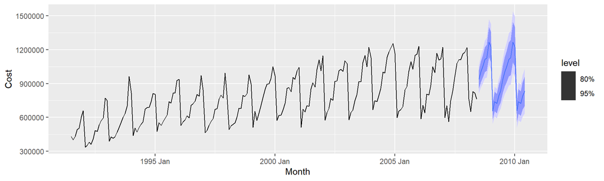

```r
h02 |>
  model(ETS(Cost)) |>
  forecast() |>
  autoplot(h02)
```

It appears to pick up the trend and seasonality nicely! We now compare the results of the automatic model and the one we chose. Though note that with this code this is done on the data, which is not that interesting (instead we would need to use a holdout set):

```r
h02 |>
  model(
    auto = ETS(Cost),
    AAA = ETS(Cost ~ error("A") + trend("A") + season("A"))
  ) |>
  accuracy()
```

```
## # A tibble: 2 × 10
##   .model .type        ME   RMSE    MAE     MPE  MAPE  MASE RMSSE    ACF1
##   <chr>  <chr>     <dbl>  <dbl>  <dbl>   <dbl> <dbl> <dbl> <dbl>   <dbl>
## 1 auto   Training  2461. 51102. 38649. -0.0127  4.99 0.638 0.689 -0.0958
## 2 AAA    Training -5780. 56784. 43378. -1.30    6.05 0.716 0.766  0.0258
```

```r
  # If we had a test set, we could also calculate the energy distance:
  #accuracy(measures = list(
  #  point_accuracy_measures,
  #  distribution_accuracy_measures
  #))
```

At least on the training set, the automatically chosen model is quite a bit better.